# Global Measles Outbreaks

Ishita Khanna

2025-07-03

This report explores global measles and rubella case trends using data from the **WHO Provisional Measles & Rubella Surveillance Dataset (2012–2025)**.

The goal of this analysis is to:

- Analyse **monthly and seasonal outbreak patterns** across countries.
- Visualise how **measles spread over time and geography**.
- Examine **reporting and surveillance quality**.
- Highlight the **preventable human impact**.

## Summary of the Dataset

This dataset covers 194 countries across 6 global regions.

The number of measles cases reported per country per year varies widely, with a **median of 21 cases** and a **maximum of 213,291** in a single country-year.

Rubella case counts are much lower, with a **median of 0 cases** and a **maximum of 40,362**. This highlights both the variability of outbreaks and under-reporting or low incidence in some regions.

## Monthly Outbreak Fingerprints (Top Countries)

To understand **seasonal patterns** in measles outbreaks, we visualise the monthly distribution of cases across the 12 most affected countries.

This reveals outbreak “fingerprints” of how measles tends to spike during specific months in different regions.

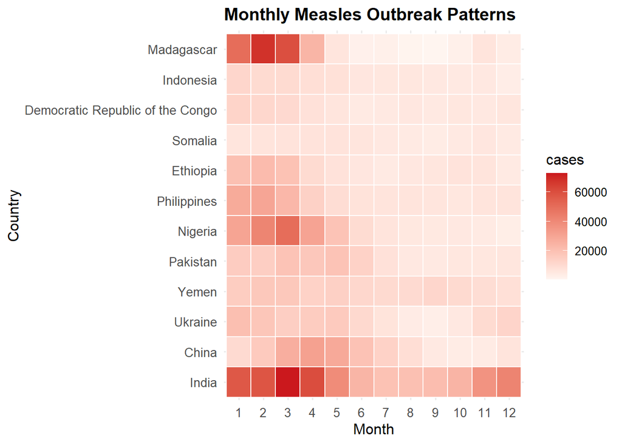